# STT 481 HW 5

##### j) Compare the test error rates between the pruned and unpruned trees. Which is higher?

```r
OJ.test.pred <- predict(OJ.tree, OJ.test, type = "class")
table(OJ.test.pred, OJ.test$Purchase)
```

```
##
## OJ.test.pred  CH  MM
##           CH 147  24
##           MM  24  75
```

```r
print(c("Unpruned test error rate",mean(OJ.test.pred != OJ.test$Purchase)))
```

```
## [1] "Unpruned test error rate" "0.177777777777778"
```

```r
OJ.prune.pred <- predict(prune.oj, OJ.test, type = "class")
table(OJ.prune.pred, OJ.test$Purchase)
```

```
##
## OJ.prune.pred  CH  MM
##            CH 147  24
##            MM  24  75
```

```r
print(c("Pruned test error rate",mean(OJ.prune.pred != OJ.test$Purchase)))
```

```
## [1] "Pruned test error rate" "0.177777777777778"
```

As one would expect, the error rates are identical again just like the training error rates were. Again, if we change the seed these will also change too.

##### k) Fit a bagging model to the training set with **Purchase** as the response and the other variables as predictors. Use 1,000 trees **(ntree = 1000)**. Use the **importance()** function to determine which variables are most important.

```r
ncol(OJ.train) - 1
```

```
## [1] 17
```

```r
bag.oj <- randomForest(Purchase ~ ., data = OJ.train, mtry = 17, ntree = 1000, importance = T)
bag.oj
```

```
##
## Call:
##  randomForest(formula = Purchase ~ ., data = OJ.train, mtry = 17,      ntree = 1000, importance = T)
##                Type of random forest: classification
##                      Number of trees: 1000
## No. of variables tried at each split: 17
##
##         OOB estimate of  error rate: 21.25%
## Confusion matrix:
##     CH  MM class.error
## CH 395  87   0.1804979
## MM  83 235   0.2610063
```

```r
importance(bag.oj)
```

```
##                          CH         MM MeanDecreaseAccuracy MeanDecreaseGini
## WeekofPurchase  11.52366903  14.338286            18.912222       36.6145004
## StoreID          7.92375214  23.042325            24.302699       11.5734760
## PriceCH          5.67055317   8.388555            10.910932        4.0779326
## PriceMM          8.73787293   4.763314            10.198585        4.9460420
## DiscCH           0.22469914   5.985853             5.124062        2.5660685
## DiscMM           6.95607100   6.192964             9.690413        2.6930698
## SpecialCH       10.10262663   4.623100            11.256978        4.7606557
## SpecialMM        0.03223215   1.952477             1.660351        2.6475442
## LoyalCH        100.53521666 155.081177           162.724141      229.1272114
## SalePriceMM      5.82645302  17.177485            17.655577       12.9825355
## SalePriceCH      8.27224617   4.471144             9.967056        5.7057716
## PriceDiff       23.63852089  29.254158            38.835960       26.9606811
## Store7           1.14107653   2.677296             2.870949        0.2638024
## PctDiscMM        6.14264310   9.370572            11.098326        3.4556880
## PctDiscCH       -0.71074959   9.106061             6.578887        3.1414427
## ListPriceDiff   15.98535230   6.008752            17.925661       17.0072410
## STORE           10.21409923  18.283972            21.360629        8.8388805
```

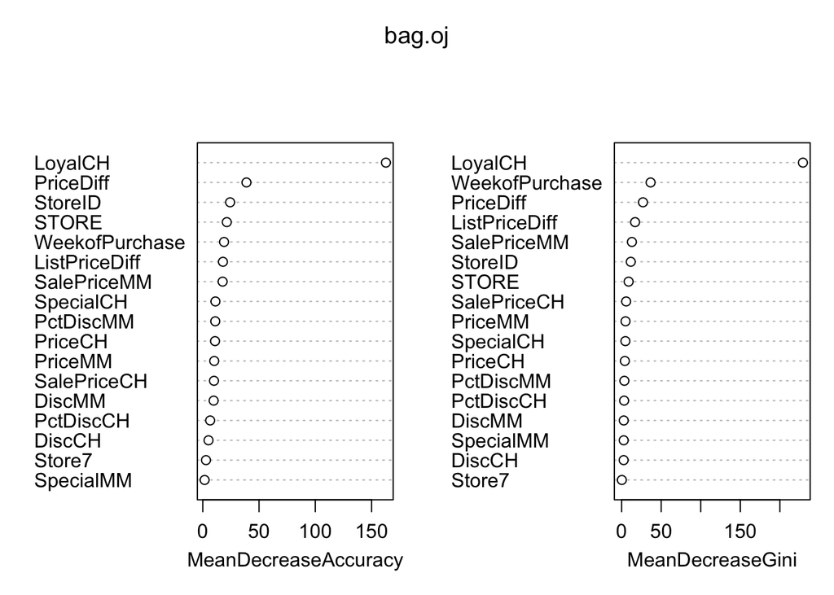

```r
varImpPlot(bag.oj)
```

##### l) Use the bagging model to predict the response on the test data. Compute the test error rates.

```r
bag.oj.pred <- predict(bag.oj, newdata = OJ.test)
table(bag.oj.pred, OJ.test$Purchase)
```

```
##
## bag.oj.pred  CH  MM
##          CH 146  21
##          MM  25  78
```

```r
mean(bag.oj.pred != OJ.test$Purchase)
```

```
## [1] 0.1703704
```

##### m) Fit a random forest model to the training set with with **Purchase** as the response and the other variables as predictors. Use 1,000 trees **(ntree = 1000)**. Use the **importance()** function to determine which variables are most important.

```r
sqrt(ncol(OJ.train) -1)
```

```
## [1] 4.123106
```

```r
rf.oj <- randomForest(Purchase ~ ., data = OJ.train, mtry = 4, importance = T)
rf.oj
```

```
##
## Call:
##  randomForest(formula = Purchase ~ ., data = OJ.train, mtry = 4,      importance = T)
##                Type of random forest: classification
##                      Number of trees: 500
## No. of variables tried at each split: 4
##
##         OOB estimate of  error rate: 20.62%
## Confusion matrix:
##     CH  MM class.error
## CH 409  73   0.1514523
## MM  92 226   0.2893082
```

```r
importance(rf.oj)
```

```
##                         CH        MM MeanDecreaseAccuracy MeanDecreaseGini
## WeekofPurchase  6.42049435 11.883905            14.536368        28.605301
## StoreID         6.15662370 18.577110            18.638258        19.046636
## PriceCH         8.02421281  5.300843            10.893290         6.292529
## PriceMM         5.05825147  3.713223             7.038659         6.716811
## DiscCH         -0.09509072  7.458482             5.201732         3.871706
## DiscMM          7.53486609  7.284313            11.122560         5.787801
## SpecialCH       4.82462999  3.016908             6.495153         3.302863
## SpecialMM       2.13968811  6.849358             7.378164         3.266877
## LoyalCH        55.70114017 79.679634            83.457143       158.258848
## SalePriceMM     9.73279538  9.273382            14.887677        13.102843
## SalePriceCH     7.05270342  7.091315            10.832771         7.724022
## PriceDiff      10.58097036 14.983896            18.781723        19.131443
## Store7          5.76605384  8.584945             9.389279         3.935823
## PctDiscMM       8.24029825  7.295805            12.754095         6.584049
## PctDiscCH       1.92374081  4.999250             4.821712         4.305319
## ListPriceDiff   9.03387988  9.187913            12.648142        11.408676
## STORE           6.59676483  9.903088            11.085625        10.989150
```

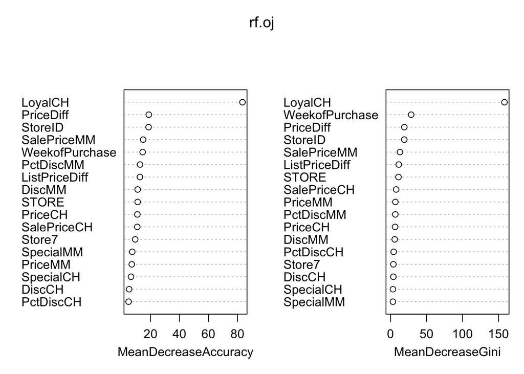

```r
varImpPlot(rf.oj)
```

##### n) Use the random forest to predict the response on the test data. Compute the test error rates.

```r
rf.oj.pred <- predict(rf.oj, newdata = OJ.test)
table(rf.oj.pred, OJ.test$Purchase)
```

```
##
## rf.oj.pred  CH  MM
##         CH 148  27
##         MM  23  72
```

```r
mean(rf.oj.pred != OJ.test$Purchase)
```

```
## [1] 0.1851852
```